# BondLog ユーザーガイド

BondLogへようこそ!このアプリは、配信者のあなたがリスナーとの大切なつながりを記録し、整理するためのお手伝いをします。

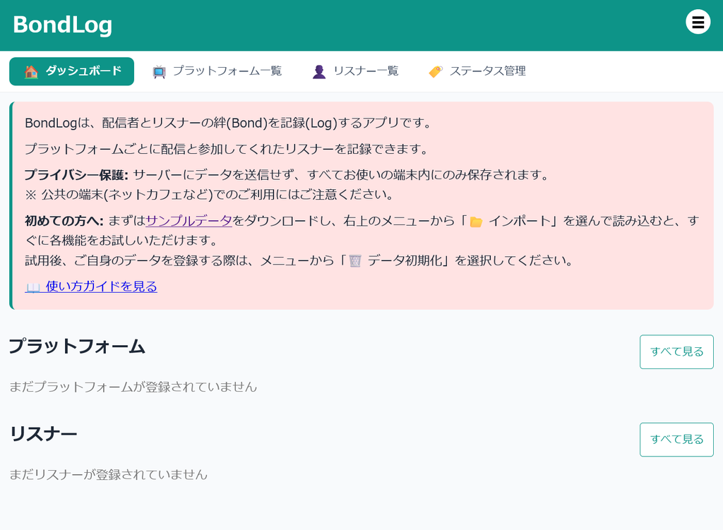

*BondLogのメイン画面*

## はじめに - BondLogって何？

BondLogは、配信活動を通じて出会ったリスナーの皆さんとのつながりを、温かく記録していくためのアプリです。

- **プライベートで安全**: データはあなたのブラウザ内だけに保存されます
  - **ブラウザのキャッシュクリアなどでデータが消える可能性があるため、定期的なバックアップをお勧めします**
  - **詳しくは「データの安全な管理」をご覧ください**
- **複数プラットフォーム対応**: YouTube、IRIAM、Palmuなど、どのプラットフォームでも使えます
- **リスナーとの絆を大切に**: 参加履歴やギフト履歴を通じて、一人ひとりとの思い出を振り返れます

## 初めての方へ - サンプルデータで試してみる

BondLog をすぐに体験したい場合は、サンプルデータをご利用いただけます。

1. **sample-data.json** をダウンロード
2. アプリ右上のメニューから「**データをインポート**」を選択
3. ダウンロードした `sample-data.json` を読み込む

サンプルデータには、2つのプラットフォーム、9人のリスナー、8件の配信履歴、複数のステータスとギフトテンプレートが含まれています。アプリの各機能を実際に操作しながらお試しいただけます。

**試用後、ご自身のデータを登録する際は**、メニューから「**データを初期化**」を選択してサンプルデータをクリアし、新規に登録を始めてください。

## 目次

- はじめに
- 初めての方へ — サンプルデータで試してみる
- つかいかた
  - 主な画面（用語の説明）
  - プラットフォーム一覧の操作
  - プラットフォームを登録しよう
  - 配信を記録してみよう
  - 登録者数の推移を記録する
  - 登録者数推移グラフを確認する
  - 配信に参加者を追加しよう
  - リスナーを登録／編集する
  - ギフトの記録
  - ステータス機能で特別な関係性を表現
- データの活用
  - 振り返りの楽しみ
  - データの並び替え
- データの安全な管理
  - バックアップ（エクスポート）
  - 復元（インポート）
  - 開発者向け：技術的メモ（任意）
- 便利な機能
- こんな使い方がオススメ
- よくある質問（FAQ）

## つかいかた

この節では、BondLog の基本的な画面構成と操作の流れを紹介します。

### 主な画面（用語の説明）

BondLog で登場する主な画面と、その呼び名が何を指すかを簡単に説明します。

- `ダッシュボード`
  - アクセス直後に表示される画面です。登録済みのプラットフォーム、リスナーが表示されます
- `プラットフォーム一覧`
  - YouTube や IRIAM など、あなたが管理する配信プラットフォームの一覧画面です
  - ここからプラットフォームの新規追加・編集・削除が行えます
  - 登録済のプラットフォームを選択するとプラットフォーム詳細へ移動します
- `プラットフォーム詳細`
  - プラットフォームを選択すると表示される詳細画面です
  - `配信一覧`
    - そのプラットフォームで行った配信の記録や過去配信の参照ができます
  - `登録者推移`
    - そのプラットフォームの登録者を記録できます
- `リスナー一覧`
  - 登録したリスナーの一覧を参照できます
  - リスナーを選択するとリスナー詳細へ移動します
- `リスナー詳細`
  - 個別リスナーの配信参加履歴・ギフト履歴・メモ・ステータスなどを確認・編集する画面です
- `ステータス管理`
  - ファンクラブや常連などのステータスを作成・管理する画面です
- `ヘッダー（タブ）`
  - ヘッダー直下のタブで画面を切り替えます
  - 主なタブは次のとおりです
    - `🏠 ダッシュボード`、`📺 プラットフォーム`、`👤 リスナー`、`🏷️ ステータス管理`
  - タイトル（BondLog）のクリックもしくは `🏠 ダッシュボード` のクリックでダッシュボードに戻ります
- `メニュー（右上の☰）`
  - データのインポート／エクスポート、データ初期化などアプリ全体の操作が行えます

### プラットフォーム一覧の操作

プラットフォーム一覧では登録したプラットフォームの一覧表示、表示順の変更、登録済プラットフォームの編集、登録済プラットフォームの削除、新しいプラットフォームの追加が行えます。

- **一覧表示**: ダッシュボードの「📺 プラットフォーム」タブまたは「すべて見る」ボタンからアクセス
- **表示順**: 「表示順」ドロップダウンで名前順（昇順／降順）を選択
- **編集・削除**: 各プラットフォームの行から編集・削除が可能（削除時は確認ダイアログが表示されます）
- **詳細へ**: プラットフォーム名をクリックすると配信一覧へ移動
- **＋ プラットフォームを追加**: 新しいプラットフォームの追加が行えます

新しいプラットフォームを追加する場合は、一覧画面右上の「＋ プラットフォームを追加」ボタンをクリックしてください。クリックすると登録用の画面が表示されます。

### プラットフォームを登録しよう

まずは、あなたが配信しているプラットフォームを登録してみましょう。

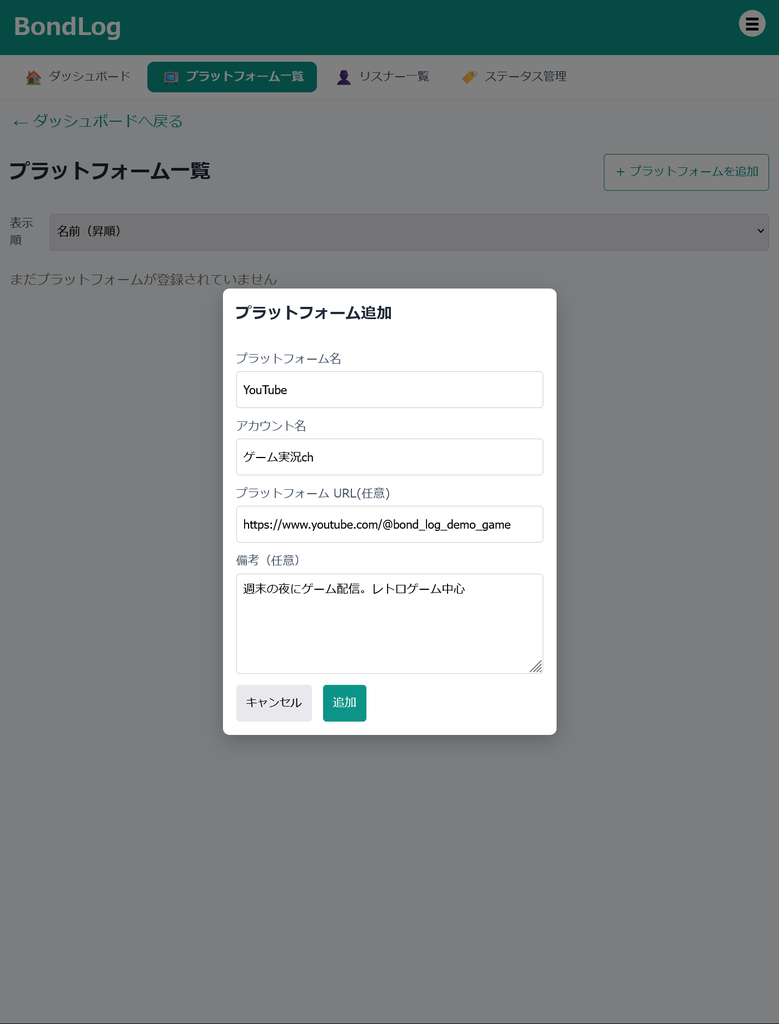

*プラットフォーム一覧画面 — 右上の「＋ プラットフォームを追加」ボタンから追加できます*

1. ヘッダー直下のタブで「📺 プラットフォーム一覧」を選択し、プラットフォーム一覧画面へ移動
2. 一覧画面右上のボタン「＋ プラットフォームを追加」をクリック
3. プラットフォーム名(YouTube、IRIAM など)を選択または入力
4. あなたのアカウント名を入力
5. チャンネル URL や備考があれば記入
6. 「追加」ボタンで完了！

### 配信を記録してみよう

プラットフォームができたら、配信の予定や記録を残してみましょう。

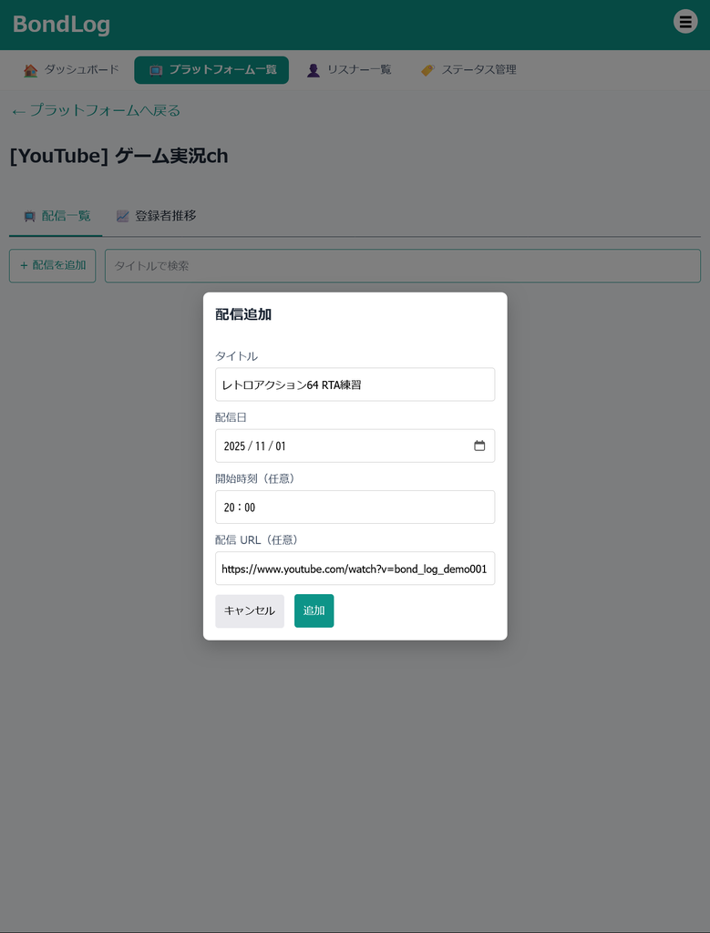

*配信追加フォーム*

1. 登録したプラットフォームをクリック
2. 「📺 配信一覧」タブで「＋ 配信を追加」をクリック
3. 配信タイトルと日付を入力
4. 開始時刻や配信URLも記録できます
5. 「追加」で配信が記録されます

### 配信一覧の操作

登録した配信は一覧で確認・管理できます。

- **検索機能**: 配信タイトルで検索可能。検索ボックスにキーワードを入力すると、一致する配信だけを表示します
- **自動ソート**: 配信は日付と時刻の新しい順（降順）に自動で並び替えられます
- **編集・削除**: 各配信行から編集・削除が可能（削除時は確認ダイアログが表示されます）

### 登録者数の推移を記録する

プラットフォームの成長を可視化するために、登録者数（登録者数）の推移を記録できます。

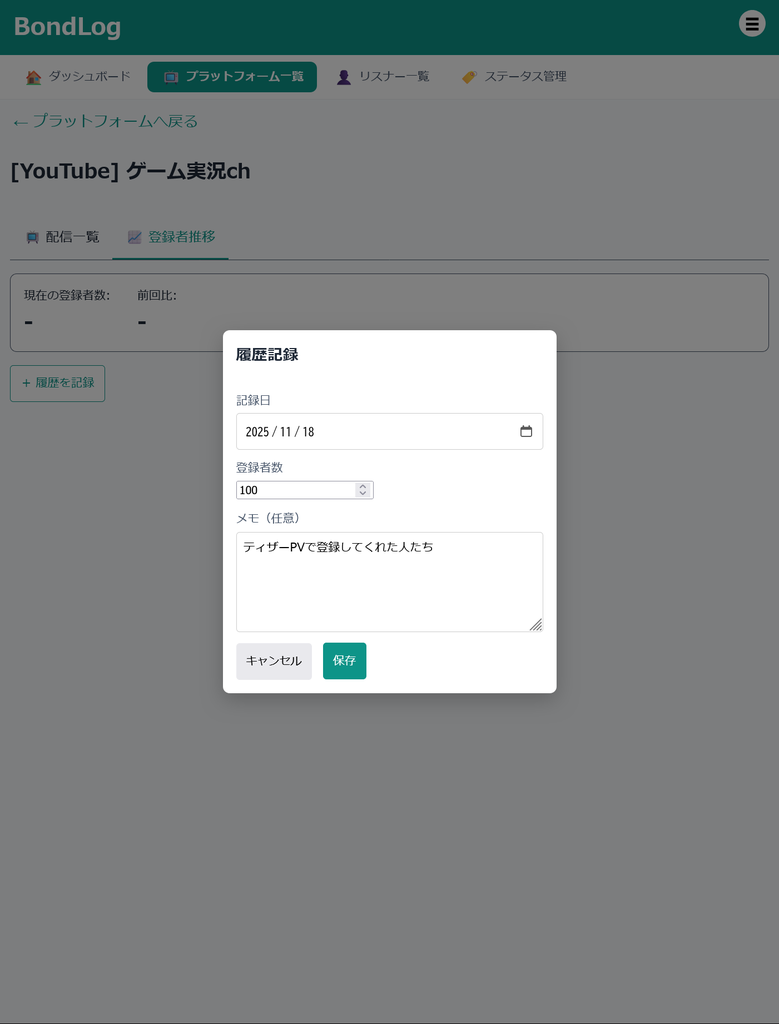

*登録者推移タブ*

1. プラットフォーム詳細画面で「📈 登録者推移」タブをクリック
2. サマリーカードで現在の登録者数と前回比を確認できます
3. 「＋ 履歴を記録」をクリックして新しい記録を追加
4. 記録日、登録者数（整数）、メモを入力して保存
   - 同じ日付に既に記録がある場合は、上書き確認が表示されます
5. 履歴リストで過去の記録を確認・編集・削除できます

### 登録者数推移グラフを確認する

ダッシュボードでは、各プラットフォームの登録者数推移を折れ線グラフで視覚的に確認できます。

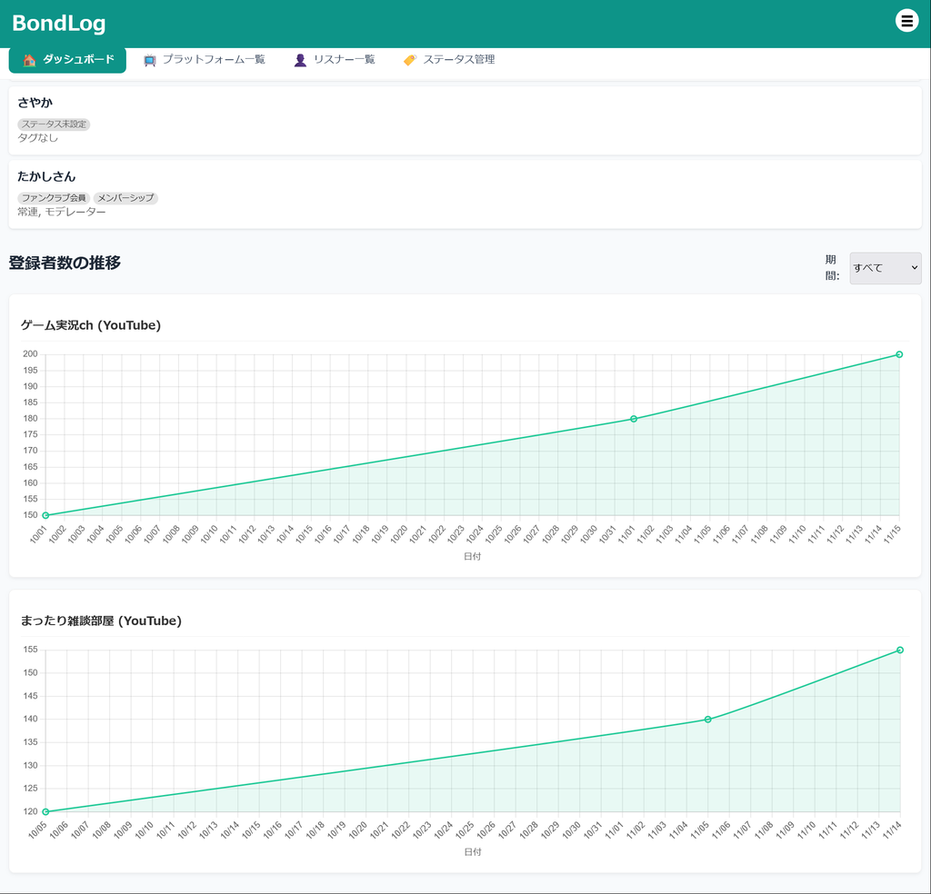

*登録者数推移グラフ例*

**グラフの見方:** - 横軸: 日付（MM/dd形式） - 縦軸: 登録者数 - 各プラットフォームごとに個別のグラフが表示されます

**期間フィルタの使い方:** 1. ダッシュボードの「登録者数の推移」セクションへ移動 2. 右上の「期間」ドロップダウンから表示期間を選択: - **すべて**: 全期間のデータを表示 - **過去1年**: 直近365日のデータを表示 - **過去6ヶ月**: 直近180日のデータを表示 - **過去3ヶ月**: 直近90日のデータを表示 - **過去1ヶ月**: 直近30日のデータを表示 3. 選択すると即座にグラフが更新されます

**注意事項:** - グラフ表示には2件以上の登録者履歴が必要です - 履歴が1件以下の場合は「データ不足」メッセージが表示されます - 登録者履歴がまったくない場合は「まだ登録者履歴を持つプラットフォームがありません」と表示されます - グラフは他のタブへ移動後、ダッシュボードへ戻ると自動的に再描画されます

## 配信に参加者を追加しよう

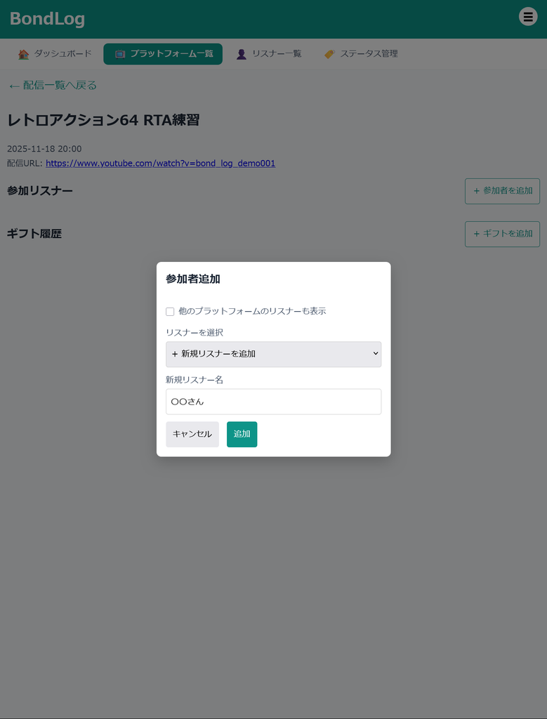

*配信詳細で参加者を追加する例*

## リスナーとのつながりを記録する

### リスナーを登録する

新しいリスナーに出会ったら、ぜひ記録してみてください。

**リスナー一覧から登録する場合:**

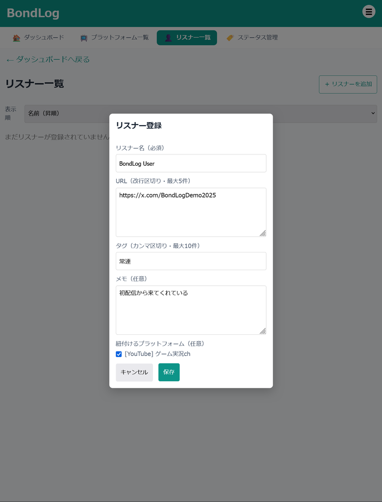

*リスナー追加フォーム*

1. ヘッダー直下のタブで「👤 リスナー一覧」を選択し、リスナー一覧画面へ移動
2. 一覧画面右上のボタン「＋ リスナーを追加」をクリック
3. リスナーを入力
4. 必要に応じてSNSのアカウントやタグやメモを追加
   - 後から編集もできるので空欄のままでもかまいません
   - タグはリスナー一覧などに表示されます
5. どのプラットフォームに登録するかを選択（複数選択可能）
   - 編集画面からの登録も可能です
   - ここで登録しなくても配信詳細から参加者を追加できます

**配信詳細から参加者として登録する場合:**

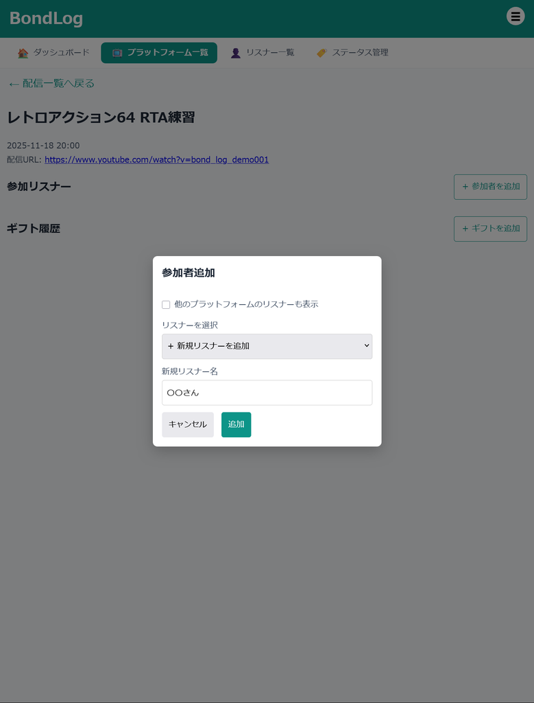

*配信詳細から参加者を追加*

**リスナーとプラットフォームの関係について:**

BondLogでは、リスナーは必ず1つ以上のプラットフォームに登録されています。たとえば、YouTubeで配信に参加してくれたリスナーをYouTubeプラットフォームに登録することで、「このリスナーはYouTubeで活動している」という関係性を記録できます。

同じリスナーが複数のプラットフォームで参加してくれる場合は、複数のプラットフォームに登録することもできます。

### リスナー情報を充実させる

リスナー詳細では、その方との思い出や情報を豊かに記録できます。

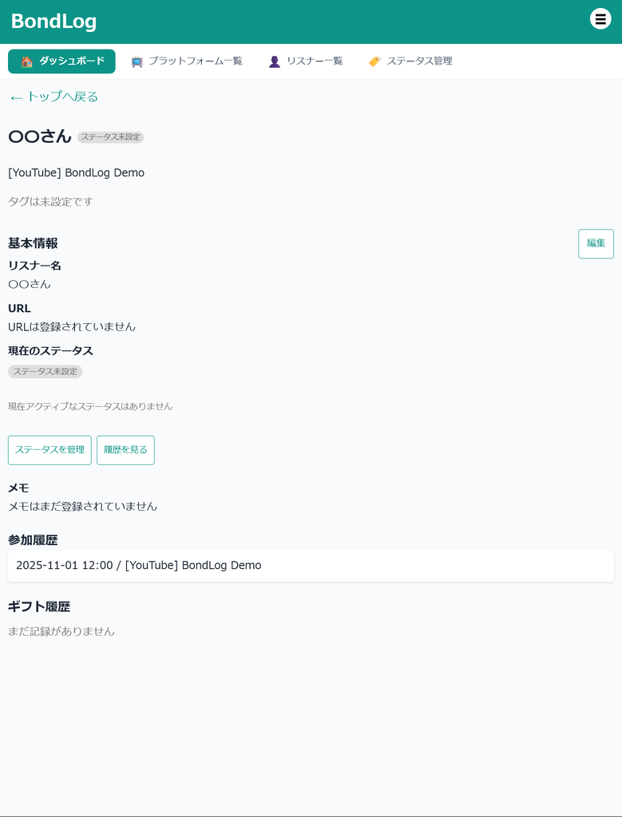

*リスナー詳細の例*

**記録・確認できる情報:**

- **基本情報**: リスナー名、SNSなどのURL、タグ、メモ
- **参加履歴**: どの配信に参加してくれたかの記録
- **ギフト履歴**: いただいたギフトの記録と合計金額
- **ステータス**: ファンクラブメンバーなどの特別な関係性

**リスナー情報の編集:**

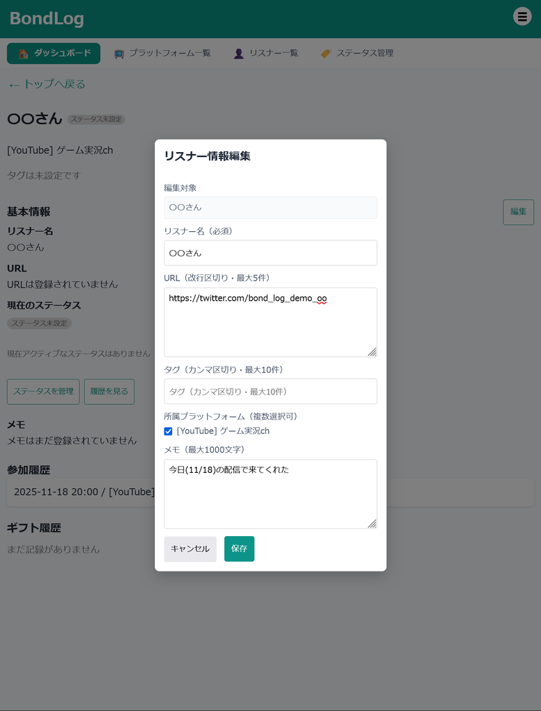

*リスナー編集フォーム*

1. リスナー一覧からリスナー名をクリックして詳細画面を開く
2. 「✏️ 編集」ボタンをクリック
3. 各項目を編集:
   - **リスナー名**: リスナーの表示名
   - **URL**: X(Twitter)やInstagramなどのプロフィールURL
   - **タグ**: カンマ区切りで複数設定可能（例: `YouTube, 常連, ゲーム好き`）
   - **メモ**: 自由記述で思い出や特徴を記録
4. 「保存」で変更を確定

## ギフトの記録

リスナーからギフトをいただいた時は、感謝の気持ちと一緒に記録しておきましょう。

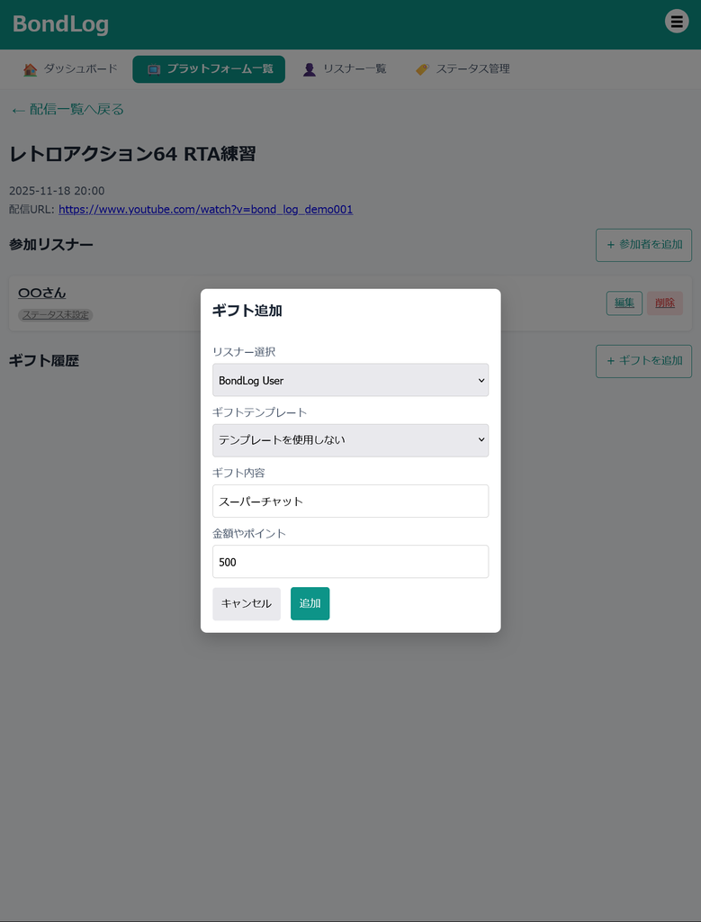

*ギフト追加フォーム*

1. 配信詳細の「＋ ギフトを追加」をクリック
2. リスナー選択でどなたからのギフトかを選択
3. ギフトの内容と金額を入力
4. よく使うギフトはテンプレートとして保存できます

### テンプレート機能

「スーパーチャット ¥1000」のように、よくいただくギフトはテンプレートとして保存しておくと、次回からは `ギフトテンプレート` を選択するだけで入力できて便利です。

## ステータス機能で特別な関係性を表現

### ステータスって何？

ステータスは、リスナーとあなたの特別な関係性を表すラベルです。バッジとして表示されるので、一目でその方との関係性がわかります。

**ステータスの活用例:** - **ファンクラブメンバー**: 月額支援をしてくれる方 - **モデレーター**: 配信のお手伝いをしてくれる方 - **常連さん**: いつも来てくれる大切なリスナー - **記念日メンバー**: 配信開始記念日から応援してくれている方

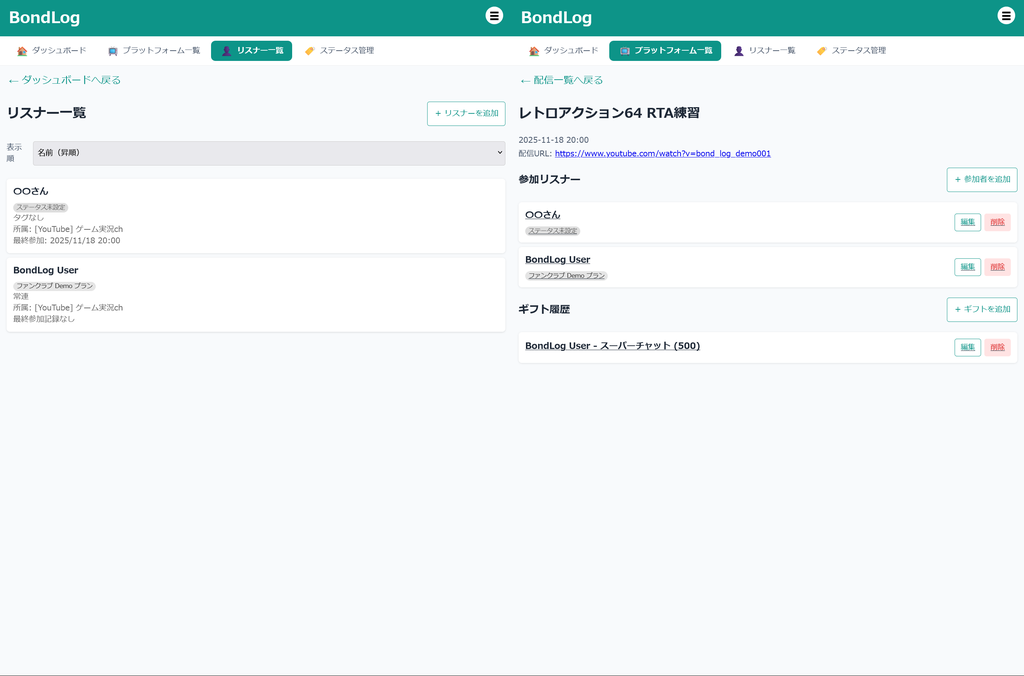

*リスナー一覧や参加者リストでバッジが表示されます(BondLog Userにバッジ「ファンクラブ Demo プラン」が追加されている)*

### ステータスを作成する

まずは、どんなステータスを使うか定義しましょう。

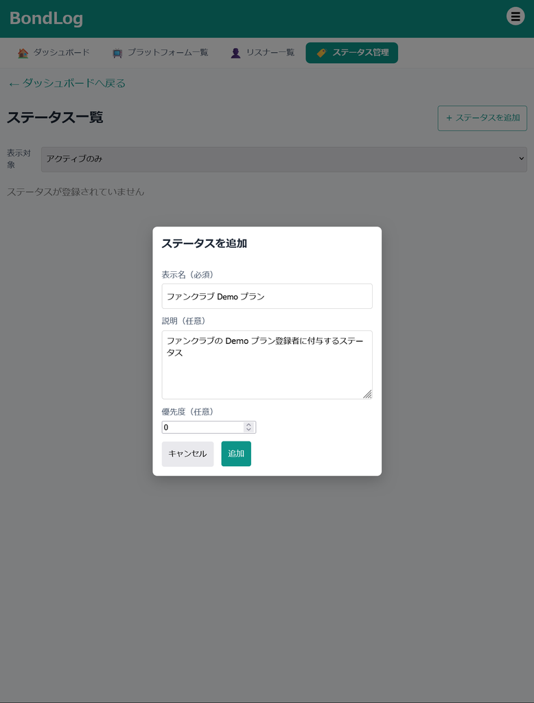

*ステータス管理画面*

**ヒント**: 表示優先度を調整することで、「ファンクラブ」を「常連」より目立たせるなど、バッジの表示順をコントロールできます。

### リスナーにステータスを付与する

ステータスを作成したら、リスナーに付けてみましょう。

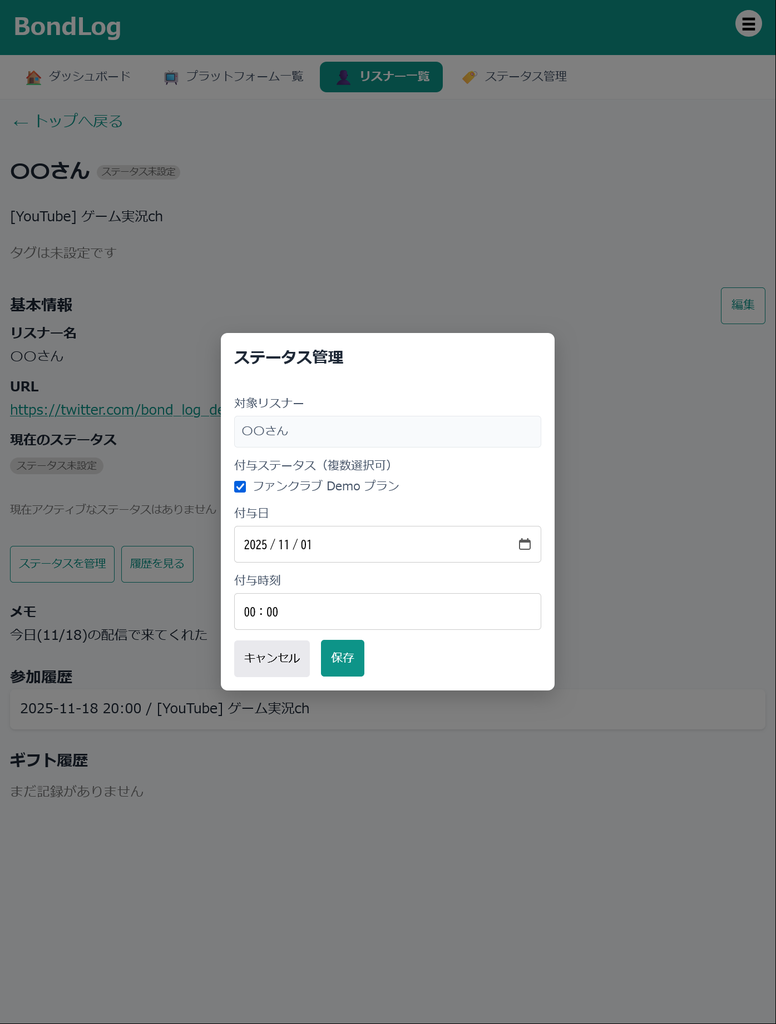

*ステータス付与*

1. リスナー一覧から対象のリスナーを選択
2. リスナー詳細の「現在のステータス」枠にある「ステータスを管理」をクリック
3. ステータス管理画面が開くので、付与したいステータスにチェックを入れる
4. **付与日時を指定**（省略可）:
   - 日付・時刻を入力すると、その日時から有効として記録されます
   - 空欄のまま保存すると、現在の日時が自動的に記録されます
   - 過去の日付も指定できるので、遡って記録することも可能です
     - 月の途中でも `1日から` と設定することが可能です
5. 「保存」をクリック

**解除する場合**: チェックを外して保存すると、その時点で解除されます。履歴は残るので、いつからいつまで有効だったかを後から確認できます。

### ステータスの履歴を確認・編集する

リスナー詳細の「履歴を見る」から、ステータスの付与・解除の記録を確認できます。

[figure not shown]

*ステータス履歴*

**履歴の見方:** - **付与日時**: いつから有効になったか - **解除日時**: いつ解除されたか（現在有効な場合は空欄） - **手動／自動**: 手動で付けたものか、外部データから取り込んだものか

**履歴の編集**（手動付与のみ）: 1. 「編集」ボタンをクリック 2. 付与日時や解除日時を修正 3. 「保存」で確定

**履歴の削除**（手動付与のみ）: - 「削除」ボタンをクリックすると、確認後にその記録が削除されます - 外部データから取り込んだ自動付与の履歴は、閲覧のみで編集・削除できません

**履歴の一覧で現在有効なステータスだけ見たい時:** - タイトル横の「現在有効のみ表示」にチェックを入れると、解除済みの履歴が非表示になります

### ステータスを編集・整理する

使わなくなったステータスは、アーカイブするか削除できます。

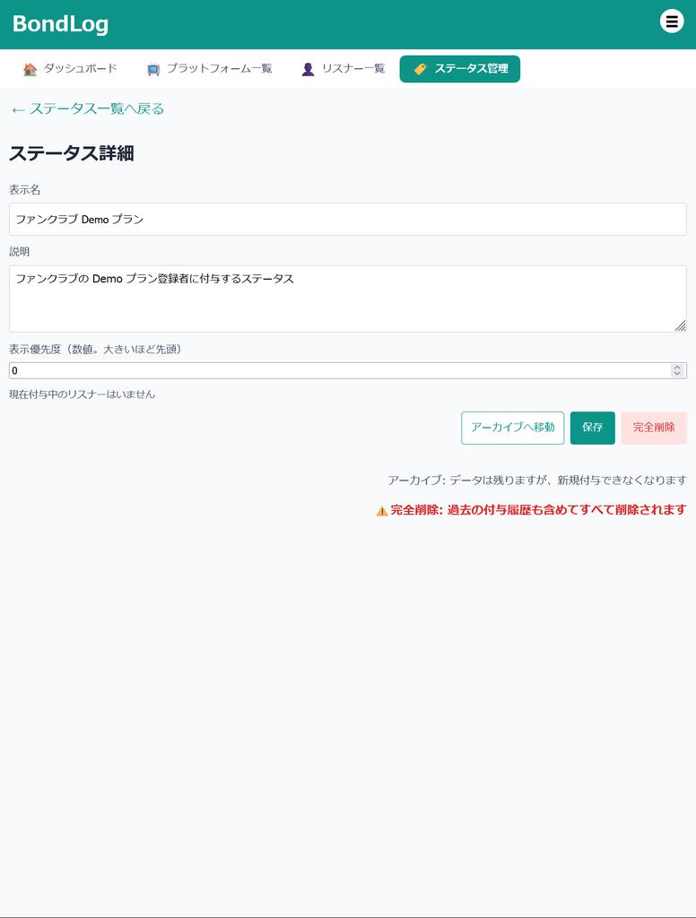

*ステータス詳細*

**アーカイブする**（おすすめ）: 1. ステータス管理画面で対象のステータスを選択 2. 「アーカイブへ移動」をクリック 3. データは残りますが、新規付与できなくなります 4. 既に付与済みのバッジはそのまま表示されます

**完全に削除する**: 1. ステータス管理画面で対象のステータスを選択 2. 「完全削除」をクリック 3. ⚠️ **過去の付与履歴も含めてすべて削除されます**（復元できません） 4. 確認ダイアログで承認すると削除されます

**ヒント**: アーカイブは「新規付与を止めるだけ」で過去のデータは残ります。誤って登録してしまった場合など完全に削除したいとき以外は、アーカイブの利用をおすすめします。

### ステータス一覧の表示設定

ステータス管理画面では、表示を切り替えられます。

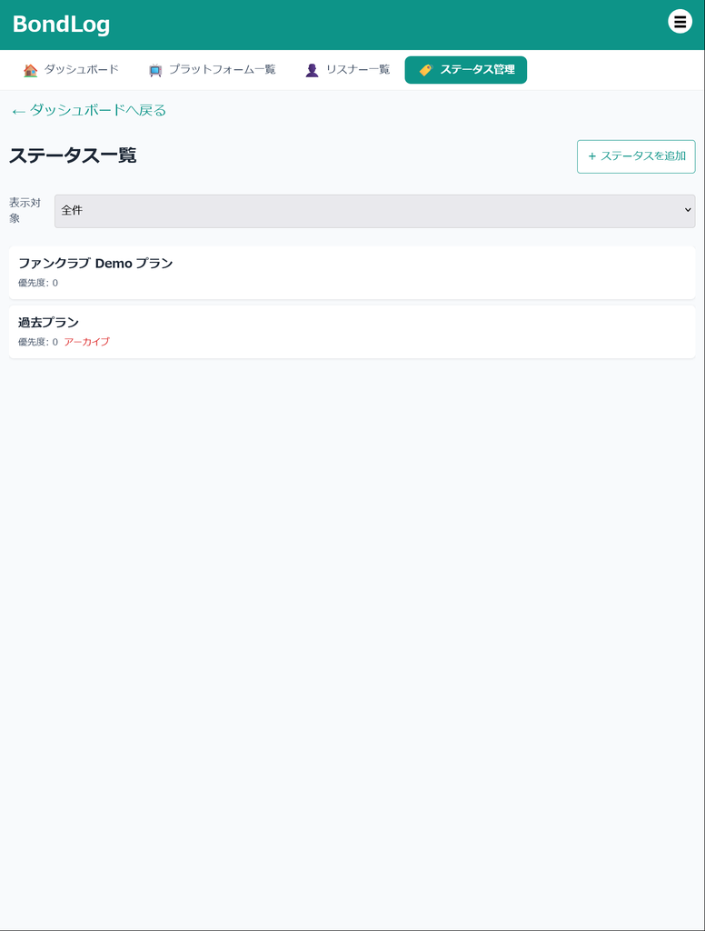

*ステータス全件*

## データの活用

### 振り返りの楽しみ

- **リスナー詳細**: その方との出会いから現在までの歩みを時系列で確認
- **参加履歴**: 「○○さんは最近よく来てくれているな」といった気づき
- **ギフト履歴**: 「今月はこんなにも支援していただいた」という感謝の確認

### データの並び替え

プラットフォーム一覧・リスナー一覧では、表示順を変更できます。

- **プラットフォーム一覧**: 名前順（昇順・降順）
- **リスナー一覧**: 名前順（昇順・降順）または最終参加日時順（新しい順・古い順）

## データの安全な管理

### ⚠️ 重要：データ保存の仕組みについて

BondLogはあなたのブラウザ内だけにデータを保存します（外部に送信しません）。そのため、誰でも簡単に使えますが、下記のような操作でデータが消える可能性があります：

- **ブラウザのキャッシュ・履歴・Cookieを削除した時**
- **ブラウザの設定をリセットした時**
- **ブラウザを再インストールした時**
- **OSを再インストールした時**
- **ブラウザの「サイトデータを消去」を実行した時**

**大切なデータを守るため、定期的にメニューから「データをエクスポート」でバックアップを取得してください。**

### バックアップ(エクスポート)

大切なデータを失わないよう、定期的にバックアップを取りましょう。

**推奨:配信の後にバックアップ**

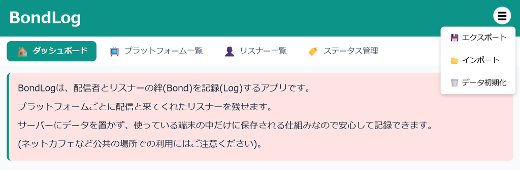

*メニューからエクスポート*

1. メニューボタン(☰)から「データをエクスポート」を選択
2. JSONファイルがダウンロードされます
3. このファイルを安全な場所に保存(クラウドストレージや外部ドライブへの保存を推奨)

### データの復元（インポート）

新しい端末に移る時や、データを復元したい時は：

1. メニューから「データをインポート」を選択
2. 保存しておいたJSONファイルを選択
3. データが復元されます

### 開発者向け：技術的メモ（任意）

（この節は技術関係者向けの短い注記です。非技術ユーザーは読み飛ばして構いません。）

- 実装メモ: BondLog はブラウザの IndexedDB（データベース名: `BondLogDB`）を用いてデータを保持しています。アプリ内の主要レコードは `profiles` オブジェクトストアの `id: "main"` に保存され、`schemaVersion` は現在 `2` です。
- インポート: エクスポートされた JSON には `schemaVersion` が含まれます。古いフォーマットは可能な限り自動正規化されますが、変換に失敗する場合があるため、インポート前に現在のデータをエクスポートしてバックアップを取ってください。
- ドキュメント表現: ユーザー向けの本文では分かりやすさのため「ブラウザに保存」としています。内部実装の詳細が必要な場合はこの注記を参照してください。

## トラブルシューティング

アプリの使用中に問題が発生した場合、以下の対処法を試してください。解決しない場合は、ブラウザを最新版に更新するか、別のブラウザ（Chrome 推奨）でお試しください。

### データが保存されない・消えた

- **原因**: ブラウザのプライバシー設定や拡張機能が IndexedDB をブロックしている可能性。
- **対処法**:
  1. ブラウザの設定で「サイトデータの削除」を確認（BondLog のデータが消えないよう注意）。
  2. 拡張機能（広告ブロックなど）を一時的に無効化。
  3. 別のブラウザで試す。
- **予防**: 定期的にエクスポートしてバックアップを取る。

### インポートが失敗する

- **原因**: JSON ファイルの形式が不正、または古いバージョン。
- **対処法**:
  1. エクスポート済みのファイルを再確認する。
  2. `schemaVersion` が一致するか確認する。
  3. 問題が続く場合はデベロッパーツールのコンソールログを確認する。

## 🔧 便利な機能

### 検索のコツ

リスナーが増えてきたら、タグ機能を活用しましょう。

- **プラットフォーム別**: 「YouTube」「IRIAM」など
- **関係性別**: 「常連」「新規」「VIP」など
- **趣味・特徴別**: 「ゲーム好き」「お絵描き好き」など

### ショートカット

- **ヘッダーのタイトルクリック**: どの画面からでもトップに戻れます
- **Enterキー**: タイトルにフォーカスがある時もトップに戻れます
- **Tabキー**: フォーム内の入力欄を順番に移動（アクセシビリティ向上）
- **Escキー**: モーダル（ポップアップ）ウィンドウを閉じる
- **F5キー**: ページをリロード（データ同期エラーの対処）

### データの初期化

新しく始め直したい時は、メニューの「データを初期化」で空の状態に戻せます（バックアップをお忘れなく！）。

## こんな使い方がオススメ

### 配信前の準備

1. 今日の配信を事前に登録
2. 常連さんのリスナー詳細を確認して、最近の話題をチェック
3. 記念日が近い方がいないかステータスで確認

### 配信中

1. 新しく来てくれた方は参加者として追加
2. ギフトをいただいたらその場で記録
3. 特別な出来事があったらメモに記録

### 配信後の整理

1. 参加してくれた方の情報を充実
2. 印象的だった方にタグを追加
3. 次回の配信に向けて、アクティブなリスナーを確認

## よくある質問

**Q: データは安全ですか？** A: データはあなたのブラウザ内にだけ保存され、外部に送信されることはありません。ただし、ブラウザのキャッシュクリアや設定リセットでデータが消える可能性があるため、定期的なバックアップ（エクスポート）を強くお勧めします。

**Q: 複数の端末で使えますか？** A: エクスポート・インポート機能を使って、データを他の端末に移すことができます。

**Q: リスナー名を変更したらどうなりますか？** A: 過去の参加履歴やギフト履歴も一緒に更新されます。

**Q: 間違って削除してしまいました** A: 削除する前に確認ダイアログが表示されますが、削除後の復元はできません。定期的なバックアップをお勧めします。

**Q: 同名のリスナーがいます** A: BondLogでは同名のリスナーも区別して管理できます。タグやメモで見分けをつけてください。

BondLogがあなたとリスナーの皆さんとの素敵な関係性を記録するお手伝いができれば嬉しいです。配信活動がより豊かで温かいものになりますように！

何かご不明な点がございましたら、機能を実際に触って試してみてください。データは安全に保管されているので、安心して色々と操作してみてください。